# CS 448B Assignment 2: Inside Airbnb

Joanne Jang

April 17, 2016

## Why I chose this dataset

Among all the presents (and love) I received on my 21st birthday earlier this month, my favorite was the [Inside Airbnb](http://insideairbnb.com) dataset Christine (who’s also taking this class) gave me. I love Airbnb– its mission and the company culture– but I’m not well-informed re: the controversy surrounding their practices, so I thought that exploring this dataset would be a great way to learn more about the controversy while sifting through (daydreaming about?) listings in NYC.

## About the dataset

The subset of the huge dataset I chose consists of review metadata, listings, and neighborhood data in New York City, NY (35957 listings) compiled on 2/2/2016. As I hinted earlier, the website hosting the dataset– insideairbnb.com– is biased; it dubs Airbnb as “illegal hotels,” and I was first hesitant to use this for my project fearing that the compilation of the data itself might have been biased. Upon reading the disclaimers and articles written about it, however, I decided to proceed because the compilation itself seemed harmless and it sounded too exciting to resist.

## Initial question

Are most Airbnb listings in NYC instances of “home-sharing” (spare-room rentals) or “illegal hotels” as its critics claim? In other words, what percentage of listings are homes that are rented out in its entirety?

```r
library(readr)
library(dplyr)
```

```r
library(ggplot2)
library(leaflet)

listings <- read_csv("~/Desktop/taking/CS448B/Airbnb/listings.csv")
reviews <- read_csv("~/Desktop/taking/CS448B/Airbnb/reviews.csv")
neighborhoods <- read_csv("~/Desktop/taking/CS448B/Airbnb/neighbourhoods.csv")
```

## Pre-exploration

```r
summary(listings)
```

```
##        id               name              host_id
##  Min.   :     105   Length:35957       Min.   :      43
##  1st Qu.: 2942732   Class :character   1st Qu.: 3416555
##  Median : 6316786   Mode  :character   Median :10837710
##  Mean   : 5830490                      Mean   :17153296
##  3rd Qu.: 8923833                      3rd Qu.:27608332
##  Max.   :10996598                      Max.   :57055185
##
##   host_name         neighbourhood_group neighbourhood         latitude
##  Length:35957       Length:35957        Length:35957       Min.   :40.51
##  Class :character   Class :character    Class :character   1st Qu.:40.70
##  Mode  :character   Mode  :character    Mode  :character   Median :40.73
##                                                            Mean   :40.73
##                                                            3rd Qu.:40.76
##                                                            Max.   :40.91
##
##    longitude       room_type             price        minimum_nights
##  Min.   :-74.24   Length:35957       Min.   :  10.0   Min.   :   1.000
##  1st Qu.:-73.99   Class :character   1st Qu.:  75.0   1st Qu.:   1.000
##  Median :-73.96   Mode  :character   Median : 115.0   Median :   2.000
##  Mean   :-73.96                      Mean   : 149.5   Mean   :   3.183
##  3rd Qu.:-73.94                      3rd Qu.: 179.0   3rd Qu.:   3.000
##  Max.   :-73.73                      Max.   :8000.0   Max.   :1250.000
##
##  number_of_reviews  last_review         reviews_per_month
##  Min.   :  0.00    Min.   :2010-05-23   Min.   : 0.010
##  1st Qu.:  0.00    1st Qu.:2015-10-19   1st Qu.: 0.420
##  Median :  3.00    Median :2015-12-28   Median : 0.920
##  Mean   : 12.21    Mean   :2015-11-03   Mean   : 1.268
##  3rd Qu.: 13.00    3rd Qu.:2016-01-05   3rd Qu.: 1.730
##  Max.   :286.00    Max.   :2016-02-02   Max.   :12.000
##                    NA's   :9037         NA's   :9037
##  calculated_host_listings_count availability_365
##  Min.   : 1.000                 Min.   :  0.0
##  1st Qu.: 1.000                 1st Qu.: 16.0
##  Median : 1.000                 Median :213.0
##  Mean   : 1.702                 Mean   :190.3
##  3rd Qu.: 1.000                 3rd Qu.:356.0
##  Max.   :41.000                 Max.   :365.0
##
```

```r
listings %>% head()
```

```
## Source: local data frame [6 x 16]
##
##        id                                name  host_id      host_name
##     (int)                               (chr)    (int)          (chr)
## 1 6627449      Large 1 BDRM in Great location 13886510         Arlene
## 2 7949480 City Island Sanctuary Sunny BR & BA   119445 Linda & Didier
## 3 1886820       Quaint City Island Community.  9815788          Steve
## 4 5557381             Quaint City Island Home 28811542         Phoebe
## 5 9019702             City Island Sugar Shack 46642112           Jody
## 6  958444 Great 1BD waterfront City Island NY  5214644         Noelva
##   neighbourhood_group neighbourhood latitude longitude       room_type
##                 (chr)         (chr)    (dbl)     (dbl)           (chr)
## 1               Bronx   City Island 40.84977 -73.78661 Entire home/apt
## 2               Bronx   City Island 40.85205 -73.78868    Private room
## 3               Bronx   City Island 40.84114 -73.78305 Entire home/apt
```

[output cut: 19 more lines]

```r
reviews %>% head()
```

```
## Source: local data frame [6 x 2]
##
##   listing_id       date
##        (int)     (date)
## 1    6987560 2015-06-29
## 2    6987560 2015-10-12
## 3    7652181 2015-08-17
## 4    7652181 2015-10-25
## 5    7652181 2015-10-30
## 6    5857673 2015-10-01
```

```r
neighborhoods %>% head()
```

```
## Source: local data frame [6 x 2]
##
##   neighbourhood_group neighbourhood
##                 (chr)         (chr)
## 1               Bronx      Allerton
## 2               Bronx    Baychester
## 3               Bronx       Belmont
## 4               Bronx     Bronxdale
## 5               Bronx   Castle Hill
## 6               Bronx   City Island
```

I see that neighborhood information has already been joined to provide neighborhood group information in listings, so I don’t need to consider neighborhoods anymore. I also don’t think I will be using reviews metadata (at least for now), so that leaves me with one (rich) data frame to work with: listings.

Some columns that will come in handy in answering my initial question are `room_type` and `availability_365`. I realized that there’s no actual booking information (e.g. how popular a certain listing is), which isn’t completely necessary in answering my question, but would be good to have as additional data. The readme page suggests a review rate of 50% to convert reviews to estimated bookings (e.g. if there are 2 reviews, we can estimate the # of actual bookings to be 4), and I’ll use that.

```r
listings <- listings %>% mutate(estimated_bookings = 2*number_of_reviews)
```

## 1. Around what percentage of all listings are entire home/apts?

```r
listings %>% group_by(room_type) %>%
    summarise(percentage = n()/nrow(listings), n =n())
```

```
## Source: local data frame [3 x 3]
##
##         room_type percentage     n
##             (chr)      (dbl) (int)
## 1 Entire home/apt 0.53583447 19267
## 2    Private room 0.43318408 15576
## 3     Shared room 0.03098145  1114
```

Around 53.6% of all listings are for entire home/apts, followed by 43.3% in private rooms and 3.1% in shared rooms.

To visualize this with a pie chart in Tableau:

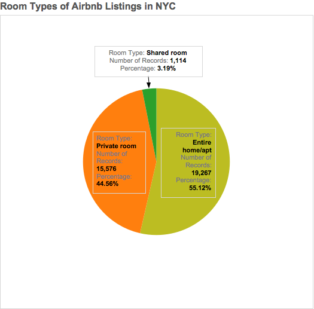

[A note about Tableau: While the above visualization was fun to make and I was thoroughly impressed by its capabilities, I found the drag-and-drop interface frustrating and time-consuming; I missed being able to do everything in R and its wonderful packages. I am definitely going to have more fun with Tableau in my free time, but for the purposes of the exploratory data analysis in which I foresee a lot of wrangling, I think I will stick to R.]

I should take into account the availability of the listings as well; if, say, an entire home is listed as available for 365 days, we know that the host does not live in that home, and more of those instances would lead Airbnb further away from the spare-room-rentals-for-homeowners-looking-to-make-a-few-extra- bucks value proposition.

## 2. Are there hosts actually running businesses off of Airbnb?

I want to examine the distribution of the # of listings each host has on Airbnb. I saw that there was a column called `calculated_host_listings_count`, but want to verify by computing it myself using the other given columns.

```r
listings %>% group_by(host_id) %>%
    summarize(my_host_listings_count = n()) %>%
    arrange(desc(my_host_listings_count)) %>%
    head()
```

```
## Source: local data frame [6 x 2]
##
##    host_id my_host_listings_count
##      (int)                  (int)
## 1 30283594                     56
## 2 25830578                     39
## 3 51913826                     29
## 4   417504                     28
## 5 26377263                     28
## 6  3250450                     26
```

```r
listings %>% select(host_id, calculated_host_listings_count) %>%
    distinct() %>%
    arrange(desc(calculated_host_listings_count)) %>%
    head()
```

```
## Source: local data frame [6 x 2]
##
##    host_id calculated_host_listings_count
##      (int)                          (int)
## 1 30283594                             41
## 2 25830578                             39
## 3 51913826                             29
## 4 24120303                             24
## 5 35927005                             18
## 6 46335228                             17
```

Whoa, the numbers are pretty different. My guess is that I’m not considering some factors `calculated_host_listings_count` considered when it was compiled?

Let’s zoom in on host id 30283594 that appeared as 1st in both versions but had a different number of listings (56 vs. 41):

```r
listings %>% filter(host_id == 30283594)
```

Piping the above command to View(), I see that some `host_name` entries are n/a even though they have the same `host_id`. Could host_name == NA matter?

```r
listings %>% filter(host_id == 30283594, !is.na(host_name)) %>% nrow()
```

[output not shown]

That was it! I’m guessing the person who compiled this data set took out all the missing values before calculating the host listings count, so listings for which `host_name` was n/a didn’t get counted. I think they should be counted, since the other columns seem to indicate that the entries are valid, so I will be using `my_host_listings_count`.

```r
listings <- listings %>% group_by(host_id) %>%
    mutate(my_host_listings_count = n())
```

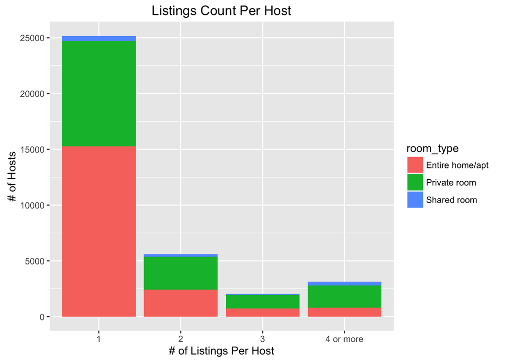

```r
listings <- listings %>% group_by(my_host_listings_count) %>%
    mutate(listings_count_tier = ifelse(my_host_listings_count == 1, "1",
                                    ifelse(my_host_listings_count == 2, "2",
                                    ifelse(my_host_listings_count == 3, "3",
                                           "4 or more"))))
listings %>%
    ggplot(mapping = aes(x = listings_count_tier, fill = room_type)) +
    geom_bar(stat = "count") +
    labs(x = "# of Listings Per Host", y = "# of Hosts",
         title = "Listings Count Per Host")
```

To answer the question, yes, there seems to be a non-trivial number of hosts with three or more listings on Airbnb (with the max number of listings being 56 as shown above), which goes against the spare-room rental value proposition I mentioned earlier.

```r
listings %>% filter(my_host_listings_count == 1,
                    (room_type == "Private room" | room_type == "Shared room")) %>%
    count()/nrow(listings)
```

```
##           n
## 1 0.2754957
```

However, ~27.5% of listings were private rooms or shared rooms owned by hosts with only one listing, which supports the value proposition.

Another way to check whether or not a number of Airbnb listings go against the mission stated is to look at the # of days available for each listing; if the listing’s `room_type` is an entire home and it’s listed as available for 365 days, we definitely know that the host doesn’t live in the home.

## 3. What is the distribution of availability of the listings in a given 365-day period?

I’d expect for it to be bimodal, with the maxima near both ends of the availability spectrum.

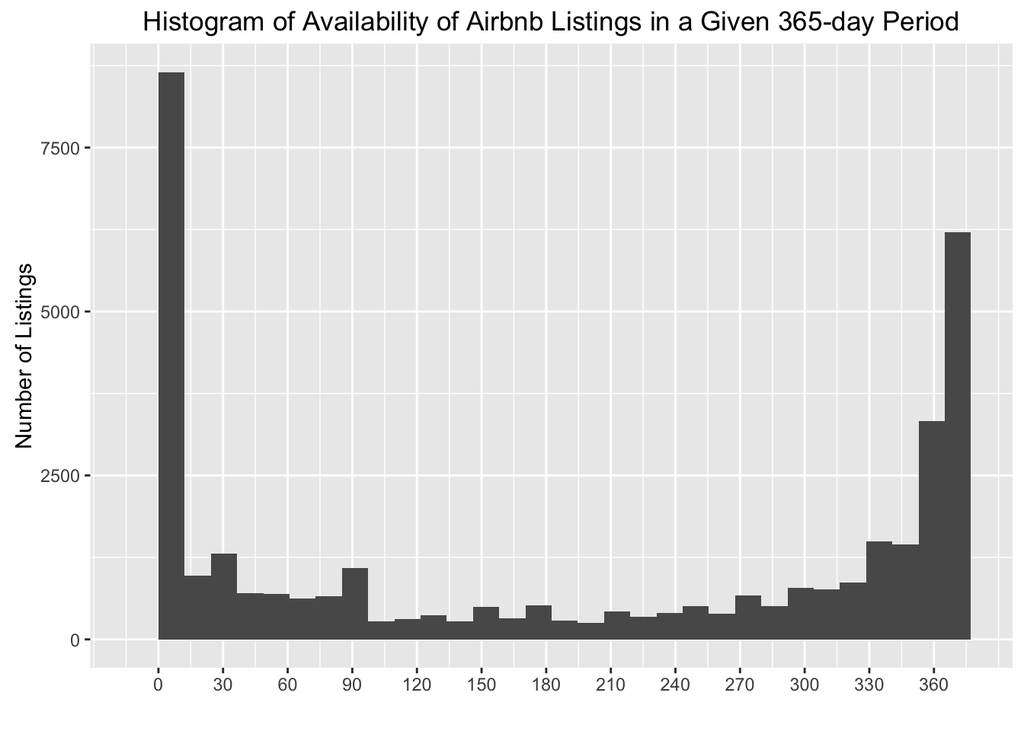

```r
listings %>% ggplot(mapping = aes(x = availability_365)) +
    geom_histogram(bins = 30) +
    labs(x = "", y = "Number of Listings",
    title = "Histogram of Availability of Airbnb Listings in a Given 365-day Period") +
    scale_x_continuous(breaks = seq(0, 365, 30))
```

Turns out it’s true. I’d like to look at the two spikes within the histogram:

```r
listings %>% filter(availability_365 < 10 | availability_365 > 355) %>%
    group_by(availability_365) %>%
    summarise(n = n())
```

```
## Source: local data frame [20 x 2]
##
##    availability_365     n
##               (int) (int)
## 1                 0  6947
## 2                 1   142
## 3                 2   122
## 4                 3   158
## 5                 4   185
## 6                 5   183
## 7                 6   127
## 8                 7   127
## 9                 8   140
## 10                9   153
## 11              356   158
## 12              357   152
## 13              358   198
## 14              359   190
## 15              360   399
## 16              361   202
## 17              362   249
## 18              363   611
## 19              364   700
## 20              365  6209
```

There are 6209 listings that are available 365 days a year (followed by 611 listings for 363 days and 700 listings for 364 days). Now I’m curious what the 1 or 2 off-days are for the houses listed as available for 363 and 364 days; could day be a specific holiday (e.g. New Year’s) when the host would like to stay at their place for once?

But perhaps more importantly:

## 4. Why are there 6947 listings for `availability_365` = 0? What does it mean for rooms to be available for 0 days?

```r
listings %>% filter(availability_365 == 0) %>% head()
```

At first glance, just looking at the head, I notice that the rows don’t seem to have anything particular in common other than neighbourhood, but this is probably because it’s implicitly arranged by neighbourhood. Could `availability_365` have to do with neighbourhood/neighbourhood_group?

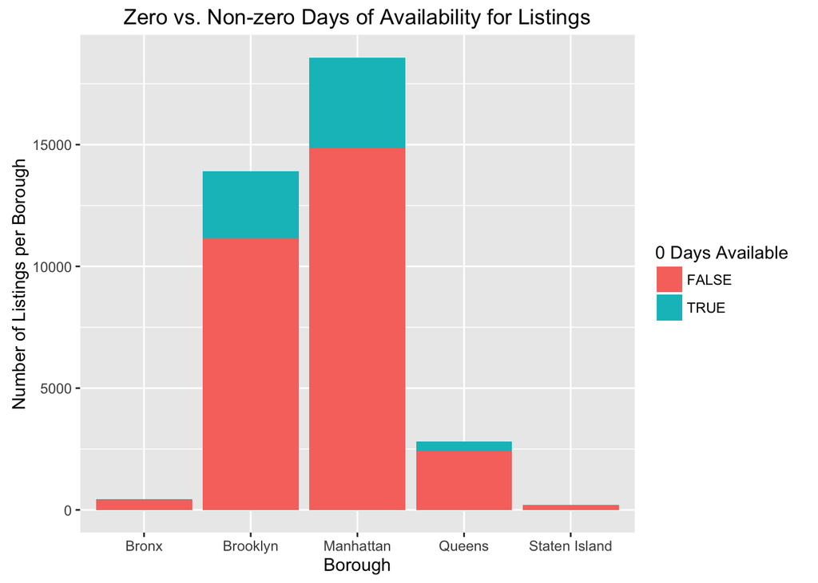

```r
listings %>% mutate(`0 Days Available` = (availability_365 == 0)) %>%
    group_by(neighbourhood_group) %>%
    ggplot(mapping = aes(x = neighbourhood_group, fill = `0 Days Available`)) +
    geom_bar(stat = "count") +
    labs(x = "Borough", y = "Number of Listings per Borough", title = "Zero vs. Non-zero Days of Availability for Listings")
```

Around 20% of listings in Brooklyn and Manhattan have availability 0, as do 13% of listings in Queens and 6-7% of listings in Bronx and Staten Island. Seeing the total numbers, though, I realize I should differentiate between popular tourist destinations and mostly residential regions. Anyway this doesn’t tell us much about the 0 available days.

Going back to the documentation, I found this tidbit: “The Airbnb calendar for a listing does not differentiate between a booked night vs an unavailable night, therefore these bookings have been counted as”unavailable“. This serves to understate the Availability metric because popular listings will be”booked" rather than being “blacked out” by a host."

This is significant. Theoretically, a house could be available for 365 days but if it’s totally booked for 363 of those days, `availability_365` would be 2. This would explain the 6947 listings figure (for which the availability variable is 0); if the house is totally booked, regardless of how many days it was initially listed as available, `availability_365` is 0. I wrongly assumed that ‘not available’ meant blocked out by the host.

## 5. Are there more listings in popular tourist destinations?

I think there would be the most number of listings in residential areas near popular tourist destinations.

```r
leaflet(listings) %>%
  addTiles() %>%
  addMarkers(clusterOptions = markerClusterOptions())
```

```
## Assuming 'longitude' and 'latitude' are longitude and latitude, respectively
```

[interactive chart not shown]

Zooming in on the cluster with the biggest count at each level, we are ultimately taken to the blocks around Tompkins Square Park, which seems to be a primarily residential area. I wish I knew more about New York City; all I know about the boroughs is that the majority of the most well-known attractions are located in Manhattan. Maybe I can use `minimum_nights` to get a rough idea of which boroughs tend to be more residential (since the bigger the `minimum_nights` value, the more likely that the host is using Airbnb to rent out his/her place)?

## 6. What is the distribution of minimum nights for each borough?

```r
listings$minimum_nights %>% summary()
```

```
##     Min.  1st Qu.   Median     Mean  3rd Qu.     Max.
##    1.000    1.000    2.000    3.183    3.000 1250.000
```

I’d expect for the distribution to be heavily skewed to near 0. I’d also expect for the median values for minimum nights to be higher in less touristy (/more residential) areas such as Queens since more people would be using it for longer-term rentals. Too many outliers (especially an insane max value like 1250) would flatten out the boxplot, so I’m going to filter out listings for which `minimum_nights` > 15 to zoom in on the boxes themselves.

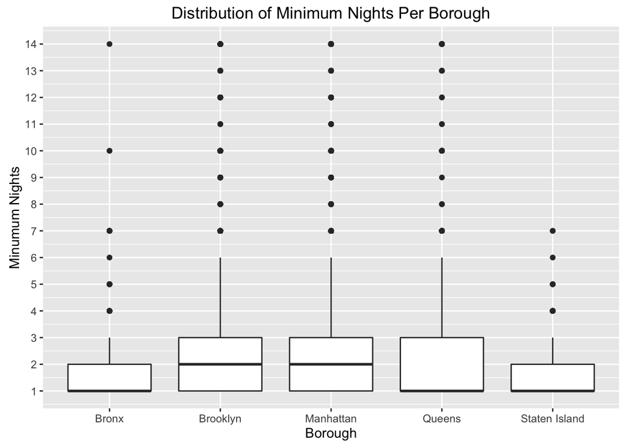

```r
listings %>% filter(minimum_nights < 15) %>%
    ggplot(mapping = aes(x = factor(neighbourhood_group),
                                  y = minimum_nights)) +
    geom_boxplot() +
    scale_y_continuous(breaks = seq(1, 20, 1)) +
    labs(x = "Borough", y = "Minumum Nights",
        title = "Distribution of Minimum Nights Per Borough")
```

It turns out I was wrong; Bronx, Queens, and Staten Island actually have the lowest median values (1) for `minimum_nights`, as opposed to Brooklyn and Manattan’s median of 2 nights. As spineless as I may sound, I can actually think of a number of explanations for this, what I think is the strongest explanation being that people wouldn’t resort to Airbnb to find longer-term housing in Queens where the platform takes a portion of the rent each night; people don’t mind paying the extra fee when quality short-term housing (especially as alternative to hotels) is extremely hard to find, as is the case for Brooklyn and Manhattan. Which brings me to price.

## 7. What is the distribution of price for each borough?

I filtered out the prices > $750 a night to make the boxes more prominent, but the number of outliers especially for Brooklyn and Manhattan is pretty telling about prices in those two boroughs.

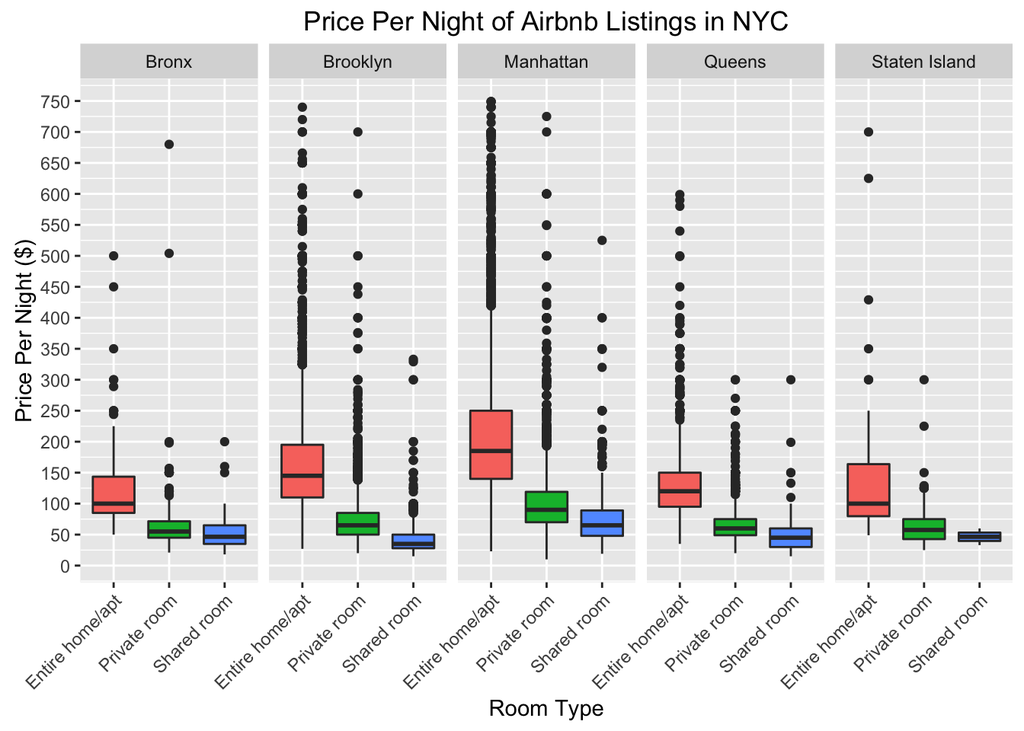

```r
listings %>% filter(price < 750) %>%
    group_by(neighbourhood_group) %>%
    ggplot(mapping = aes(x = room_type, y = price, fill = room_type)) +
    geom_boxplot() +
    facet_grid(~ neighbourhood_group) +
    theme(axis.text.x = element_text(angle = 45, hjust = 1)) +
    scale_y_continuous(breaks = seq(0, 750, 50)) +
    labs(x = "Room Type", y = "Price Per Night ($)",
        title = "Price Per Night of Airbnb Listings in NYC") +
    theme(legend.position = "none")
```

## 8. Final Visualization: Roughly how much have existing hosts earned by using Airbnb?

To visualize this I need to be hand-wavy about the following assumptions:

- Estimated bookings, as mentioned in the pre-exploration section, is calculated using the 50% review rate rule.
- Each booking was `minimum_nights` long; this, by definition, puts a lower bound on the total number of nights per booking.
- Price for each listing has stayed constant throughout time.

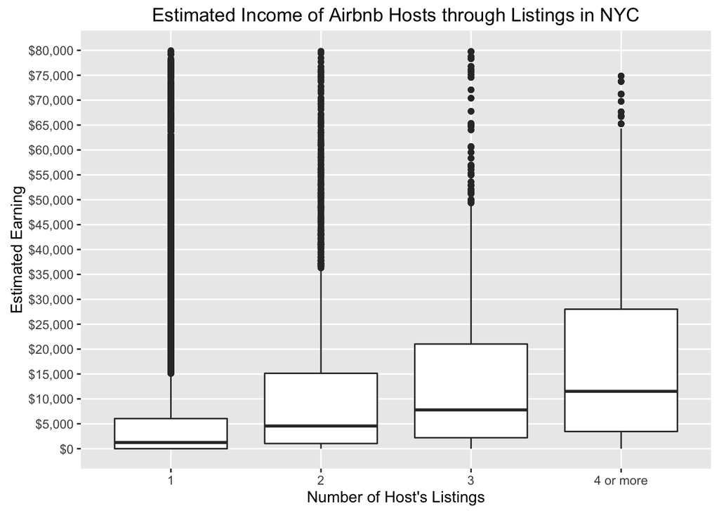

```r
listings %>% group_by(host_id) %>%
    mutate(estimated_earning = sum(estimated_bookings*price*minimum_nights)) %>%
    filter(estimated_earning < 80000) %>%
    ggplot(mapping = aes(x = factor(listings_count_tier), y = estimated_earning)) +
    geom_boxplot() +
    scale_y_continuous(labels = scales::dollar, minor_breaks = NULL,
                       breaks = seq(0, 80000, 5000)) +
    labs(x = "Number of Host's Listings", y = "Estimated Earning",
    title = "Estimated Income of Airbnb Hosts through Listings in NYC") +
    theme(legend.position = "none")
```

Note: Outliers above $80,000 were removed to facilitate the reading of the visualization. The surcharge that Airbnb places on top of price was not deducted, so the estimated income should be lower than the calculated estimate by that much.

*Caption: Estimated income was calculated as the sum of (`estimated_bookings` * `price` * `minimum_nights`) for each listing owned by the host. The median income (through Airbnb listings) per host increases roughly linearly as the number of listings increases, which may imply that the listings are booked at a similar rate regardless of how many other listings the host owns.*

Throughout the exploratory data analysis I used Airbnb’s value proposition as a guide to determine whether or not the business facilitates home-sharing (“to make a few extra bucks”) or illegal hotel operations. The visualization highlights a few interesting points; the sheer number of outliers, especially for hosts with one or two listings, testify to the variance of home rental places in New York City. As with any service, there are lots of users who have benefited greatly from it, but they are statistical outliers as the boxplot suggests. The median values (which seem to increase roughly linearly with the number of listings) support the idea that, considering the housing prices in New Yok City, the income from Airbnb listings do serve as additional income but in many cases not enough to be primary.